# Trades Demographic Analysis

Jon Stone

2023-01-23

# Trades Demographic Analysis

This is a demographic overview of CMTN’s Trades programs, from AY 2018-2019 to the 2022-2023. This analysis uses the GRD sections exclusively for student count, grades, and registration status.

# How many students do we have?

*Basic Student count by Academic Year. Students can be duplicated if they are registered in more than one program in a given academic year*

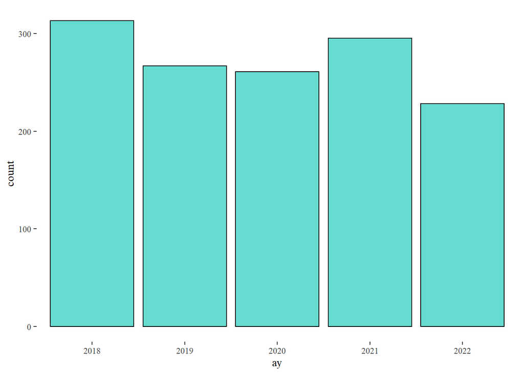

### Ok, but what about by program?

*In a table format as it is otherwise too many groups*

| SEC_DEPTS | 2018 | 2019 | 2020 | 2021 | 2022 |
| --- | --- | --- | --- | --- | --- |
| AUAPP | 8 | NA | 14 | 6 | 3 |
| AUTOF | 11 | 10 | 5 | 6 | 8 |
| CARPA | 46 | 49 | 56 | 63 | 55 |
| CARPF | 8 | 12 | 22 | 14 | 19 |
| ELAPP | 38 | 25 | 37 | 42 | 43 |
| ELTRF | 16 | 9 | 10 | 15 | 25 |
| HDET | NA | 18 | 11 | NA | NA |
| HMF | 16 | 8 | 12 | 11 | 13 |
| MILLF | NA | NA | NA | NA | 10 |
| MILLW | 7 | 16 | 6 | NA | 5 |

[output cut: 7 more lines]

### What are the ages of our students?

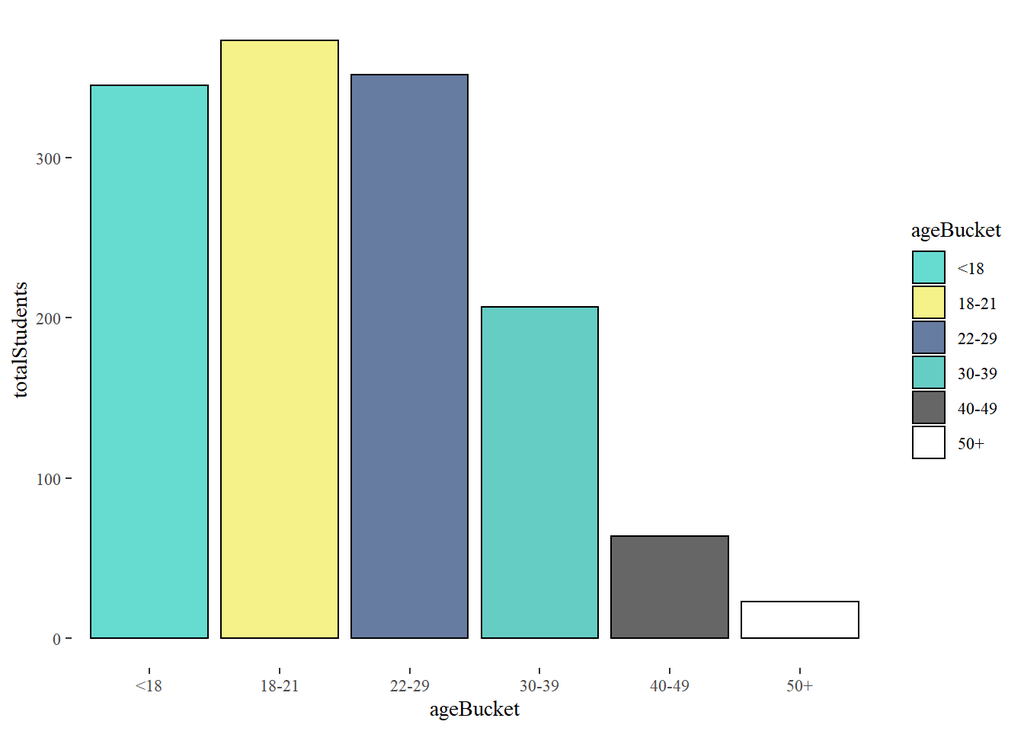

The most common age range for our students is between the 18-21 category. The vast majority of the <18 students come from the YETS program.

# Gender Analysis

### What is the split by Gender?

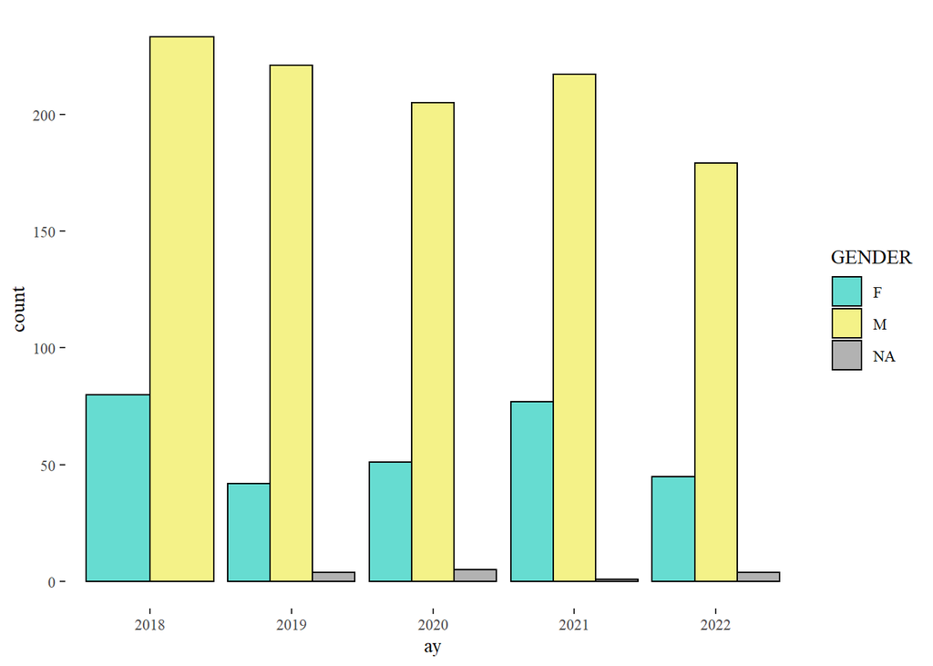

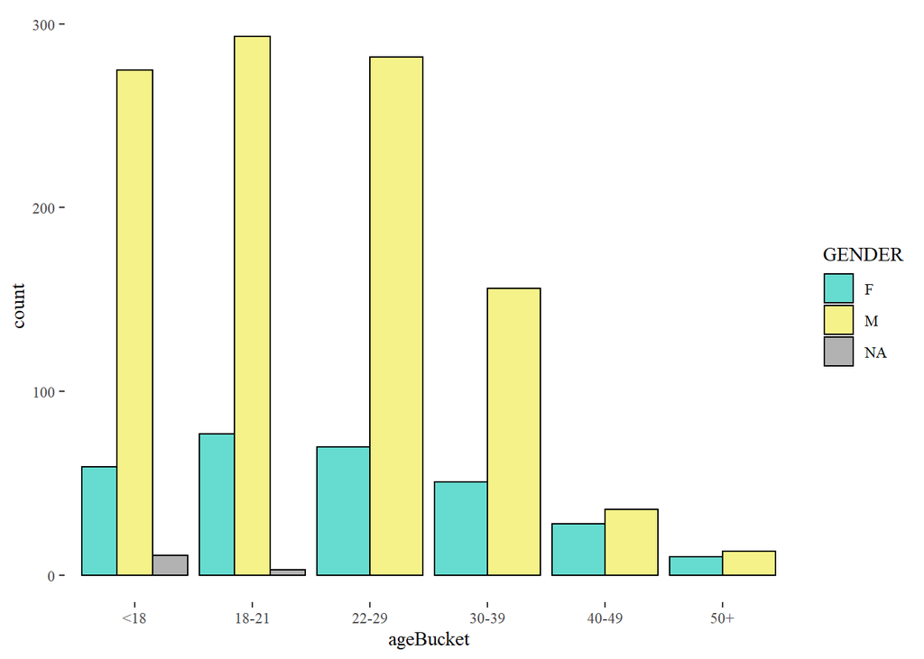

In older cohorts, women are much more likely to be a larger % of the entire cohort.

### Are there any observable trends in Foundation/Apprenticeship?

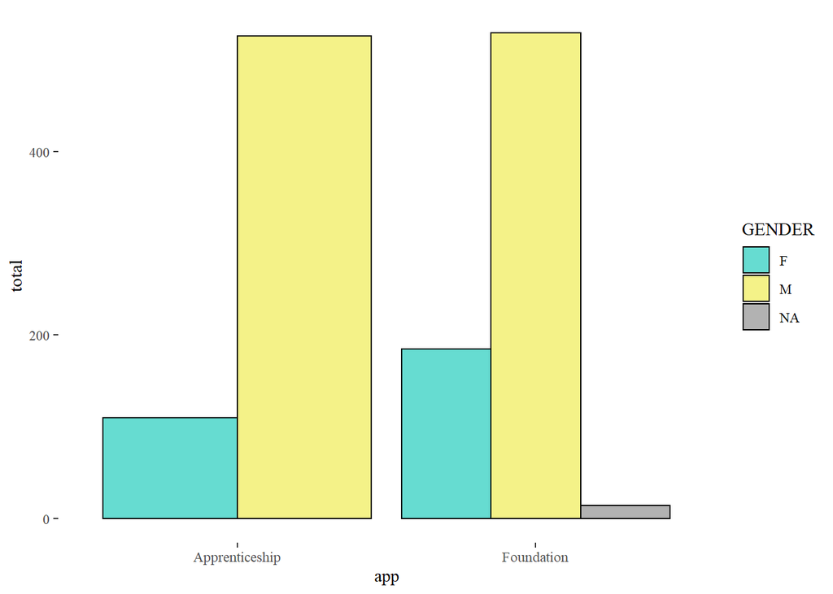

Women are much more likely to be a foundation student, rather than an apprentice student. This is due to the most common trades programs for women to enroll in are ESTH/HAIR/NAIL, as we will see next.

### Which trades programs have the highest (and lowest) % of female students?

*This takes the total across 2018 -> 2023. The larger the bar, the greater the % of female students in the cohort, to a maximum of 100%, or 1.*

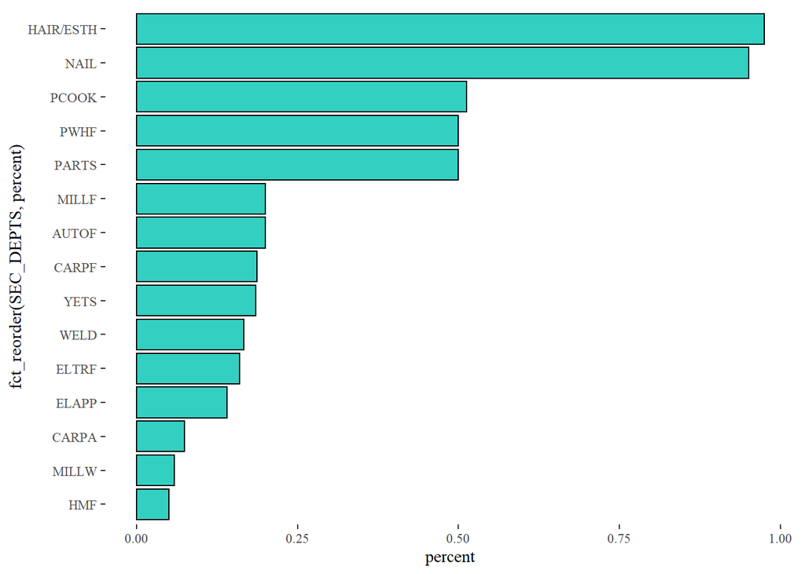

HAIR/ESTH and NAIL are predominantly enrolled by women. PCOOK, PWHF, and PARTS are approximately 50% for each gender, while the remainder of the trades programs are enrolled predominantly by men.

### Are female students more or less likely to succeed in trades programs?

*This compares completion rates (any completion with a grade >= 70% in the GRD section) across self-identified gender. The greater the bar, the greater the rates of completion for that group to a maximum of 1*

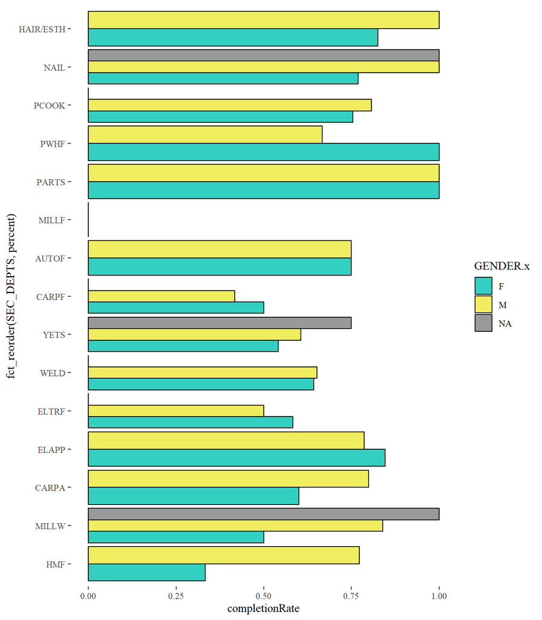

Notably, the programs which have the lowest % of female students (CARPA, HMF) also have the greatest discrepancy between success rates across male/female.

# Aboriginal Analysis

*These analyses are similar to above, but examine based on self-declared ethnicity*

### What is the split by Ethnicity?

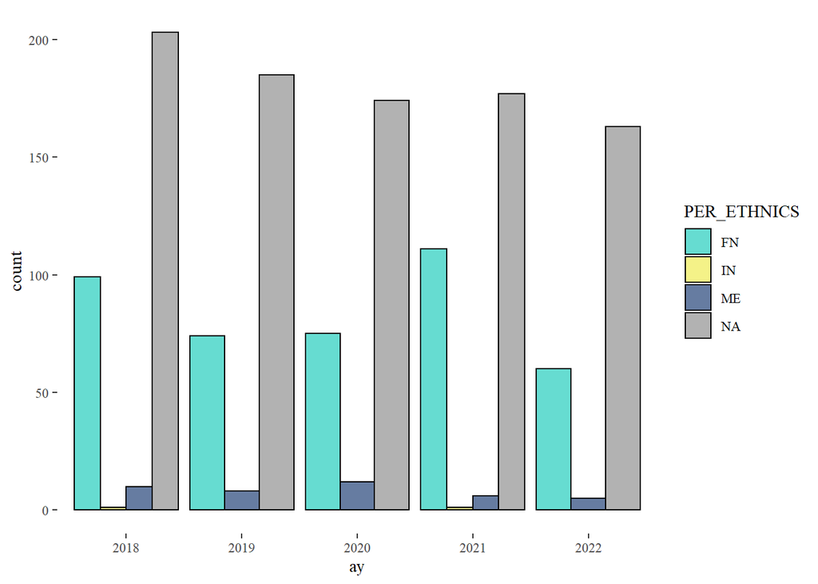

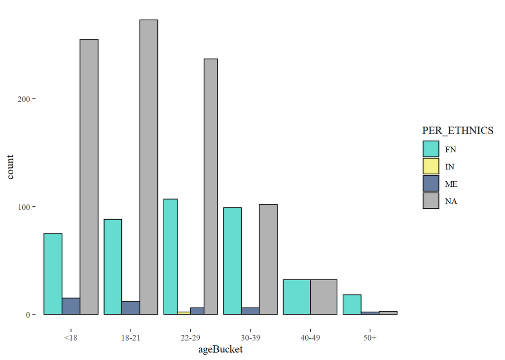

Aboriginal students are more likely to be older than our non-aboriginal students.

### Are there any observable trends in Foundation/Apprenticeship?

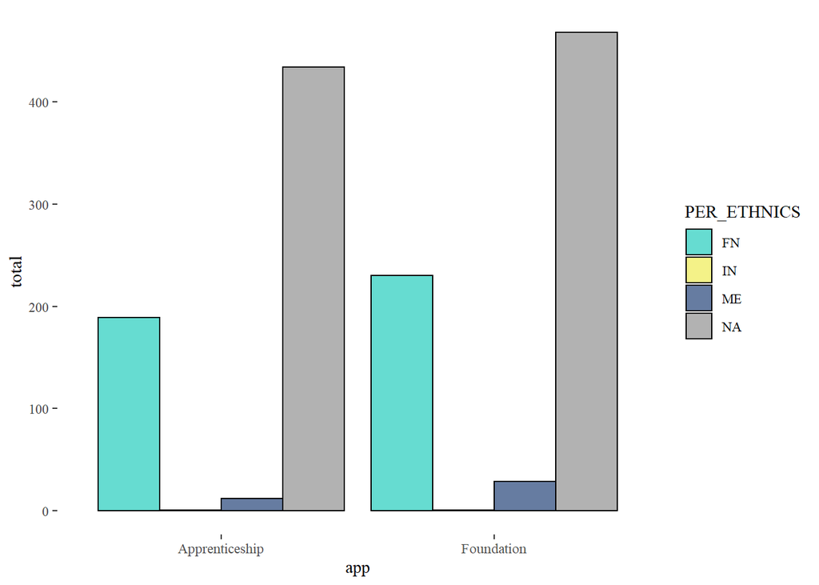

Aboriginal students make up a roughly equal % of the foundation cohort as they do the apprenticeship cohort.

### Which trades programs have the highest (and lowest) % of Aboriginal students?

*This takes the total across 2018 -> 2023.*

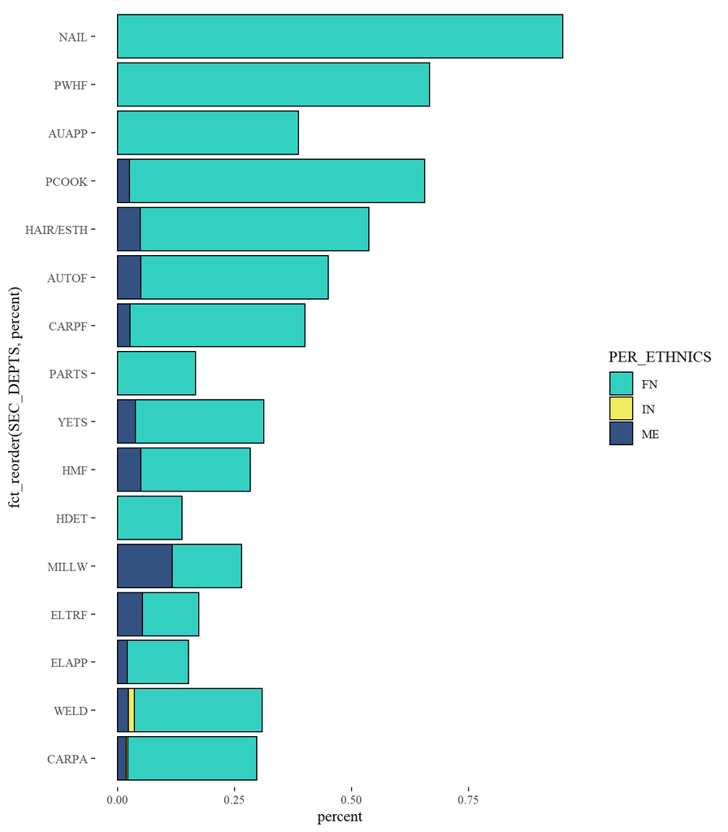

Aboriginal students are much less likely to enroll in PARTS, HDET, ELTRF, and ELAPP than would be expected.

### Are Aboriginal students more or less likely to succeed in trades programs?

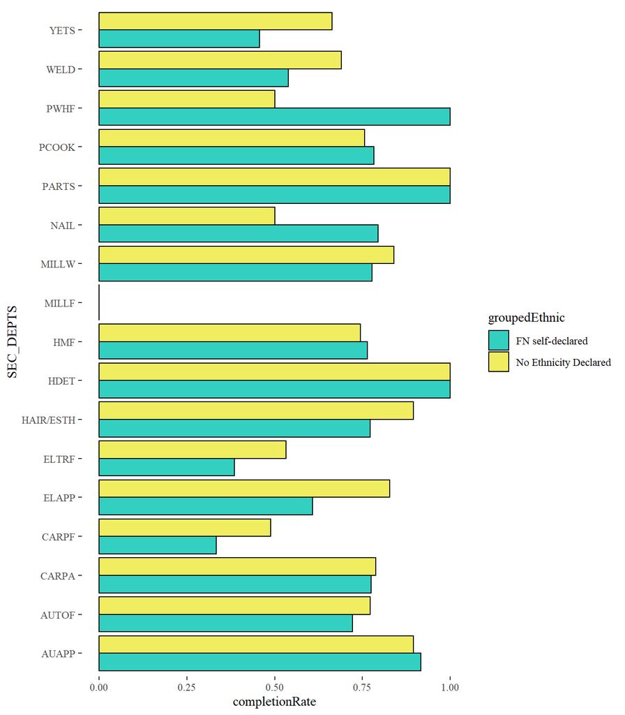

There are significant differences in rates of success for Aboriginal students in multiple programs, including ELTRF, ELAPP, YETS, WELD, CARPF.